# RERconverge Analysis Walkthrough

September 09, 2026

This walkthrough provides instructions for implementing the RERconverge package to identify genes whose evolutionary rates shift in association with change in a trait. For information on how to download and install RERconverge, see the [wiki](https://github.com/nclark-lab/RERconverge/wiki/install). Source code and a quick start guide are available on [github](https://github.com/nclark-lab/RERconverge).

# Overview

The following document describes the steps necessary to perform a standard RERconverge analysis to identify genomic elements with convergent **rates of evolution** in phenotypically convergent species using a **binary** trait or a **continuous** trait.

**Output** is a the list of genomic elements with statistics that represent the strength and directon of the relationship between the genomic element’s evolutionary rate and the phenotype. These statistics can be used to make inferences about the genomic elements’ importances to the phenotype. Genomic elements that evolve more *slowly* for a given phenotype may be under *increased evolutionary constraint* because their function is important for the development of the convergent phenotype, for example. On the other hand, genomic elements that evolve more *quickly* for a given phenotype may either be under *decreased evolutionary constraint* due to loss of function or relatively decreased functional importance or, conversely, undergoing *directional selection* to increase or alter functionality. The ranked gene list can be further used as input for functional enrichment methodologies to find pathways or other functional groups under convergent evolutionary pressures.

## Data Input Requirements and Formatting

The analysis requires two sources of data as input:

1. Phylogenetic trees for every genomic element with branch lengths that represent element-specific evolutionary rates
   - Trees should be in Newick format with tip labels and no node labels
   - Tree topologies must all be subsets of the same master tree topology
2. Species-labeled phenotype values
   - Species labels must match tree tip labels
   - For continuous traits:
     - a named numeric vector of trait values
   - For binary traits:
     - a vector of foreground species names OR
     - a Newick tree with branch lengths 0 for background branches and values between 0 and 1 for foreground branches (for a basic analysis, set all foreground branches to 1) OR
     - the user can specify foreground branches (which will be set to 1) using an interactive tool (see below)

We now provide tools for users to estimate approximate maximum likelihood trees from nucleotide or amino acid alignments using the `pml` and `optim.pml` functions from the [phangorn](https://cran.r-project.org/web/packages/phangorn/index.html) package (Schliep 2011).

When choosing a dataset to work with, consider the availability and accuracy of both genomic and phenotypic data, and be sure to select a valid convergent phenotype that is observed in multiple independent clades in your phylogeny, and at high and low levels for continuous traits.

For a more detailed description of data formatting requirements and examples, please see the relevant sections of the walkthrough.

# Analysis Walkthrough

## Installing and loading RERconverge

*Note*: Prior to running the vignette, be sure to follow all the steps for installation on the [wiki](https://github.com/nclark-lab/RERconverge/wiki/install), up to the “Install from Github” step.

In R, load the RERConverge library.

```r
if (!require("RERconverge", character.only=T, quietly=T)) {
    require(devtools)
    install_github("nclark-lab/RERconverge", ref="master")
    #"ref" can be modified to specify a particular branch
}
library(RERconverge)
```

This should also download all the files we will be working with to your computer, in the directory where your R library lives. If you’d like to visualize or work with any of these files separately, this is where you can find them:

```r
rerpath = find.package('RERconverge') #If this errors, there is an issue with installation
print(rerpath)
```

```
## [1] "/home/sol/R/x86_64-pc-linux-gnu-library/4.5/RERconverge"
```

## Reading in gene trees with `readTrees`

To run RERconverge, you will first need to supply a file containing **gene trees** for all genes to be included in your analysis. This is a tab delimited file with the following information on each line:

Gene_name Newick_tree

An example file is provided in *inst/extdata/subsetMammalGeneTrees.txt*, which you can view in any text editor.

Now in R, read in the gene trees. The `useSpecies` input variable can be provided to most RERconverge functions. Excluding one or more species from this vector will exclude them from the analyses. We leave `useSpecies` null here, but you can feed in a list of species you want to limit the trees to if you desire:

```r
toytreefile = "subsetMammalGeneTrees.txt"
toyTrees=readTrees(paste(rerpath,"/extdata/",toytreefile,sep=""), useSpecies=NULL)
```

```
## Using readTrees 2
```

```
## Read  500  items
```

```
## Done
```

```
## Max number of species is  62
```

```
## Extracting paths
```

```
## Estimating master tree branch lengths from 71 genes
```

```
## Naming columns of paths matrix
```

First, the code tells us that there are 500 items, or gene trees, in the file. Then it says that the maximum number of tips in the gene trees is 62 and, later, it reports that it will use the 71 genes in this set that have data for all 62 species to estimate a **master tree**. The master tree will be used for subsequent analyses.

RERconverge is intended to be used on genome-scale datasets, containing a large number of gene trees with data present for all species. It thus has a minimum number of such gene trees required for `readTrees` to use to estimate a **master tree**; this is set with the `minTreesAll` option and is 20 by default. If your dataset is smaller, you may adjust this or supply your own master tree using the option `masterTree` (this should be a `phylo` object generated using ape’s `read.tree`); however, we recommend interpreting results with caution in this case. If you want to read in less trees than your whole dataset for time purposes, set the `max.read` argument to however many gene trees you want it to read in.

## Estimating relative evolutionary rates (RER) with `getAllResiduals`

The next step is to estimate **relative evolutionary rates**, or RERs, for all branches in the tree for each gene. Intuitively, a gene’s RER for a given branch represents how quickly or slowly the gene is evolving on that branch relative to its overall rate of evolution throughout the tree.

Briefly, RERs are calculated by normalizing branch lengths across all trees by the master branch lengths. Branch lengths are then corrected for the heteroskedastic relationship between average branch length and variance using weighted regression. For a more detailed description of how RERs are computed, see (Chikina, Robinson, and Clark 2016) and (Partha et al. 2017).

We will use the `getAllResiduals` function to calculate RERs. This uses the following input variables (all the options set here are also the defaults):

- `useSpecies`: a vector that can be used to specify a subset of species to use in the analysis. Here we will use the species in our AdultWeightLog vector that will be used for continuous trait analysis. Note that these are also the same species used for binary trait analysis. These species should be a subset of species included in `toyTrees$masterTree$tip.label`.
- `transform`: the method used to transform the raw data. By transforming the raw data, we reduce the heteroscedasticity (relationship between mean and variance) and the influence of outliers. Here we will use a square-root transform (“sqrt”), which has performed the best at reducing heteroskedasticity in our datasets. Also available are “none” (no transformation) and “log” (natural logarithm transformation) and “asinh” (inverse hyperbolic sine transformation).
- `n.pcs`: Number of principal components to normalize by (default: 0, mean normalization).
- `use.weights`: whether to use a weighted regression to estimate RER. Weighting allows further correction for the relationship between mean and variance, which can be directly estimated from the data.
- `weights`: Manual weights for a weighted regression. If these aren’t provided, it uses ones generated in `readTrees`.
- `norm`: A character string specifying the normalization method. Options include “scale,” “zscore,” or “quantile” (default is “scale”).
- The documentation provides other specific parameters for those who want to fine tune their analysis.

Here is the basic method, with the recommended settings:

```r
data("logAdultWeightcm")
mamRERw = getAllResiduals(toyTrees,useSpecies=names(logAdultWeightcm),
                          transform = "sqrt", n.pcs = 0, use.weights = T,
                          weights=NULL,norm="scale")
```

```
## computing unweighted predictions
```

```
## computing weighted residuals on a subset
```

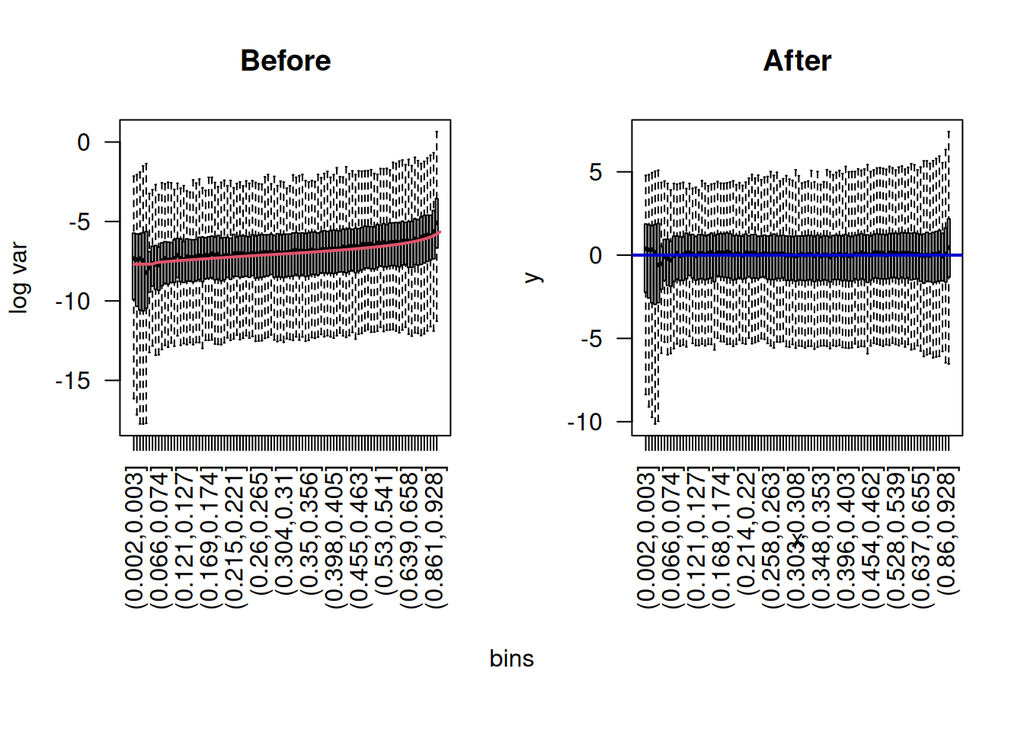

```
## cutoff is set to 0.00529150262212918
```

```
## using average normalization vector
```

```
## using included weights
```

```
## Species from master tree not present in useSpecies: Cape_golden_mole
```

```
## studentizing residuals with weights
```

```
## using column-wise scale normalization
```

The plots generated by this function show the log variance of the RERs resulting from the original method (on the left) and the variance after transformation and weighted regression (on the right). Notice the heteroscedasticity (positive trend between values and their variance) that is present before the new transformation method is applied, is now gone. The x-axis displays bins of branch lengths on the tree, and the y-axis is the (log-scaled) variance in these branch lengths across trees. As you can see by comparing the right plot to the left plot, transforming and performing a weighted regression reduces the relationship between the mean branch length (x-axis) and the variance in branch length (y-axis). You can alter values for `transform`, `n.pcs`, `use.weights`, and `norm` to attempt to optimize heteroskedasticity correction.

If you wish to save this RER object for later, you can use R’s `saveRDS` function. This will allow you to load it later with `readRDS`, using a different name, if you wish.

```r
saveRDS(mamRERw, file="mamRERw.rds")
newmamRERw = readRDS("mamRERw.rds")
```

Now that we have RERs, we can visualize these for any given gene using the `plotRers` function. Here is an example.

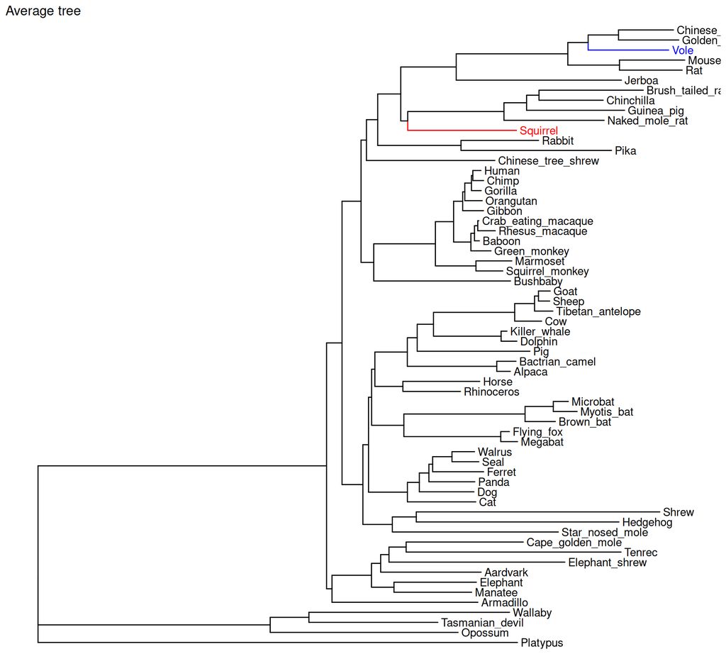

```r
#make average and gene tree plots
noneutherians <- c("Platypus","Wallaby","Tasmanian_devil","Opossum")

avgtree = plotTreeHighlightBranches(toyTrees$masterTree, outgroup=noneutherians,
                                  hlspecies=c("Vole","Squirrel"), hlcols=c("blue","red"),
                                  main="Average tree") #plot average tree

bend3tree = plotTreeHighlightBranches(toyTrees$trees$BEND3, outgroup=noneutherians,
                                    hlspecies=c("Vole","Squirrel"), hlcols=c("blue","red"),
                                    main="BEND3 tree") #plot individual gene tree
plot(avgtree)
```

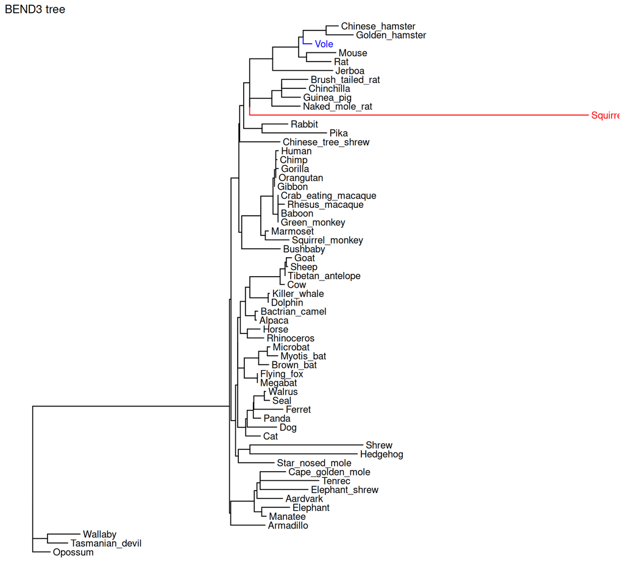

```r
plot(bend3tree)
```

The first plot is a tree with branch lengths representing the average rates across all genes. The second plot is the same tree, but with branch lengths representing rates specifically for the BEND3 gene.

Now, we’ll move onto creating a phenotype vector. The function `foreground2Paths` creates a phenotype vector of all paths that lead only to foreground species. A quick check of some (arbitrary) relevant indices in this case reveal that they’re denoted with 0 and 1 - this is binary data. Later we will discuss continuous phenotypes.

```r
#plot RERs
par(mfrow=c(1,1))
phenvExample <- foreground2Paths(c("Vole","Squirrel"),toyTrees,clade="terminal")
phenvExample[590:620]
```

```
##  [1] 1 1 1 1 1 1 1 1 1 1 1 1 0 0 0 0 0 0 0 0 0 0 0 0 0 0 0 0 0 0 0
```

Now we’re ready to plot our RERs

```
## Used an  unweighted Kendall correlation.
```

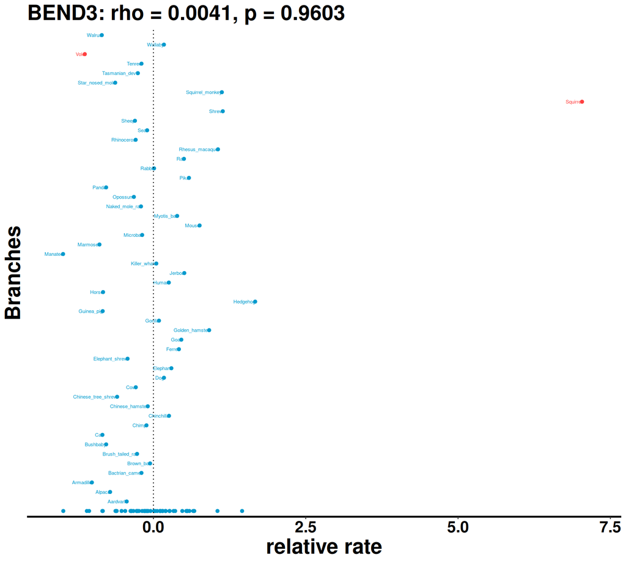

```r
plotRers(mamRERw,"BEND3",phenv=phenvExample) #plot RERs
```

This plot represents the estimated RERs for terminal branches (labeled with species names along the y-axis) and internal branches (plotted in a single row at the base of the y-axis). The foreground branches (set here using `foreground2Paths`) are highlighted in red; these are currently only terminal branches, but if any internal branches were included, there would be a red point or points among the RER points at the base of the y-axis. Notice how the RER for vole is negative; this is because the branch leading to vole in the BEND3 tree is shorter than average. On the other hand, the RER for squirrel is positive because the branch leading to squirrel in the BEND3 tree is longer than average.

If you want to change the names on the plot between scientific and common names for display purposes, you can use the `species_from` and `species_to` arguments of plotRers. Anything from the first list will be translated to its corresponding element in the second. Here we provide an example ()

```
## Used an  unweighted Kendall correlation.
```

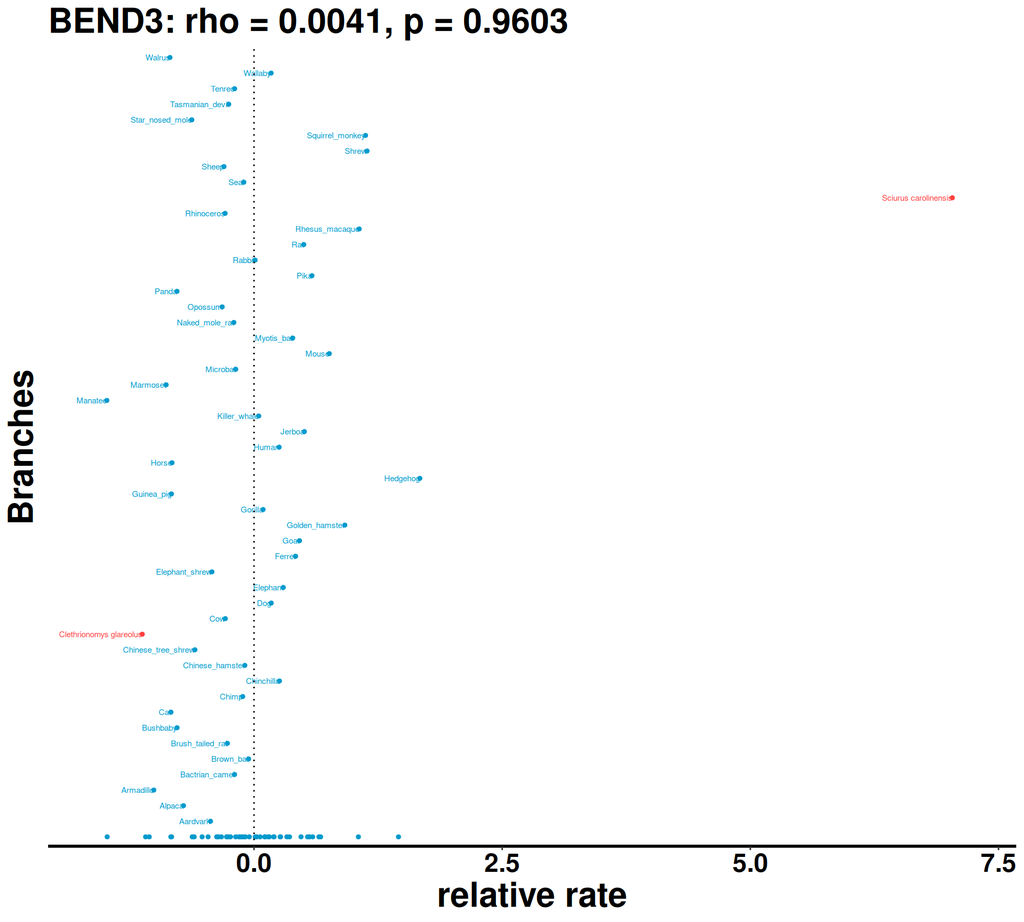

```r
names_from = c("Squirrel","Vole")
names_to   = c("Sciurus carolinensis", "Clethrionomys glareolus")

plotRers(mamRERw,"BEND3",phenv=phenvExample, #main plotting function
         species_from=names_from,species_to=names_to) #optional name translation parameters
```

We can also save all RERs for a given gene using the `returnRersAsTree` function. If we include `plot=TRUE`, this function will also generate a cladogram for the gene tree with branches labeled with their RERs.

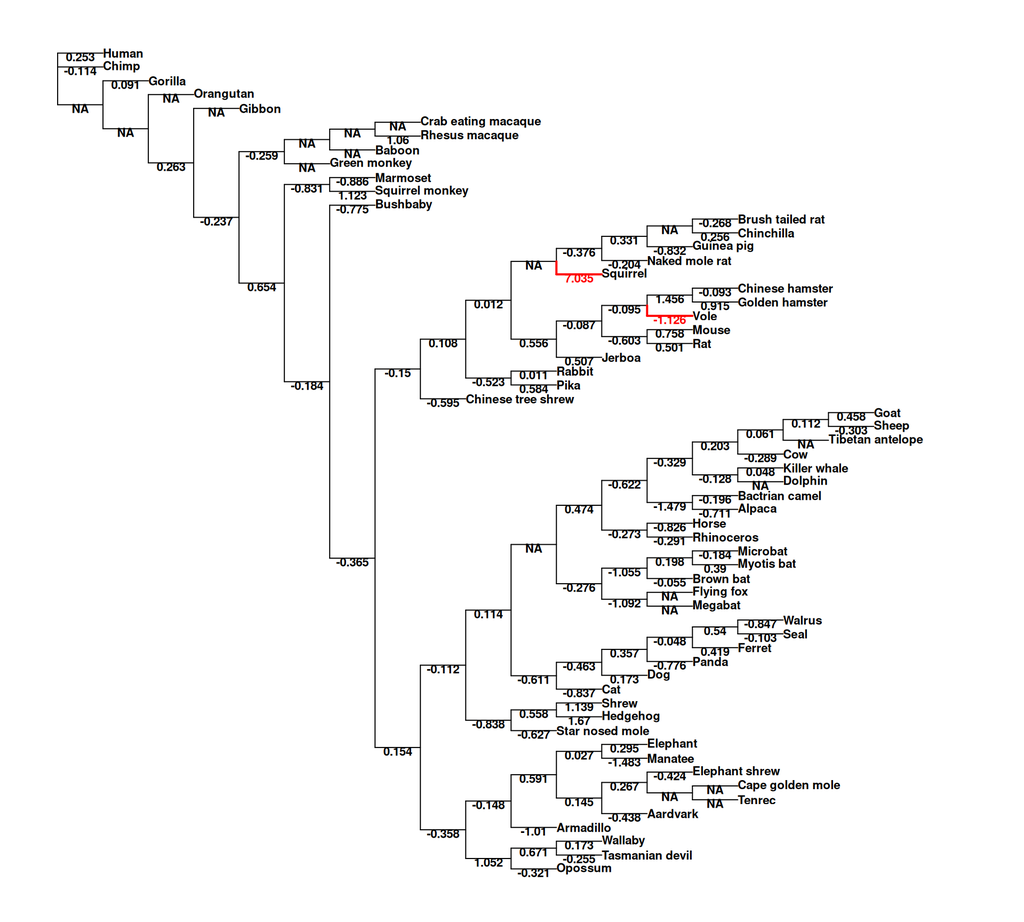

```r
#plot RERs as tree
par(mfrow=c(1,1))
bend3rers = returnRersAsTree(toyTrees, mamRERw, "BEND3", plot = TRUE,
                             phenv=phenvExample) #plot RERs
```

This function also returns a tree whose branch lengths represent the RERs for this gene. We can print or save the tree using the *ape* package function `write.tree`:

```r
strwrap(gsub(":",write.tree(bend3rers),replacement=": "))
```

```
##  [1] "(((((((((((Opossum: -0.3206826895,(Tasmanian_devil:"
##  [2] "-0.2548430888,Wallaby: 0.1725723235): 0.6707964035):"
##  [3] "1.051549515,(Armadillo: -1.00973192,((Aardvark: -0.4382098518,((Tenrec:"
##  [4] "NA,Cape_golden_mole: NA): NA,Elephant_shrew: -0.424207284):"
##  [5] "0.267317115): 0.1452597698,(Manatee: -1.482690536,Elephant:"
##  [6] "0.2949443908): 0.0269376586): 0.590951378): -0.14753451):"
##  [7] "-0.3579291326,((Star_nosed_mole: -0.6268114544,(Hedgehog:"
##  [8] "1.670290031,Shrew: 1.138850077): 0.5580631755): -0.8379715671,((Cat:"
##  [9] "-0.8367102432,(Dog: 0.1734374695,(Panda: -0.7759875722,(Ferret:"
## [10] "0.4186163938,(Seal: -0.1029667007,Walrus: -0.8468777283):"
## [11] "0.5400500142): -0.04756544055): 0.3573535578): -0.4629238436):"
## [12] "-0.6109495061,(((Megabat: NA,Flying_fox: NA): -1.092039111,(Brown_bat:"
## [13] "-0.05462036317,(Myotis_bat: 0.3897477253,Microbat: -0.184429587):"
## [14] "0.1975463472): -1.055488784): -0.2760063461,((Rhinoceros:"
## [15] "-0.2910686476,Horse: -0.8262456102): -0.272590991,((Alpaca:"
```

[output cut: 21 more lines]

```r
write.tree(bend3rers, file='BEND3RER.nwk')
```

The function `returnRersAsTreesAll` will produce an object of class “multiPhylo”, with each element containing a named gene tree with branch lengths representing RERs for that gene. This can then be used for further analysis or customized plotting, and it can be saved to a file using `write.tree`.

```r
multirers = returnRersAsTreesAll(toyTrees,mamRERw)
write.tree(multirers, file='toyRERs.nwk', tree.names=TRUE)
```

Another useful function for visualizing RERs for a given tree is `treePlotRers`. When called with `type = label`, it will produce the same plot as shown above, i.e., a cladogram with the branches labeled by RER. Alternatively, when called with `type = color`, it will produce a cladogram with RERs displayed as a color heatmap on the branches.

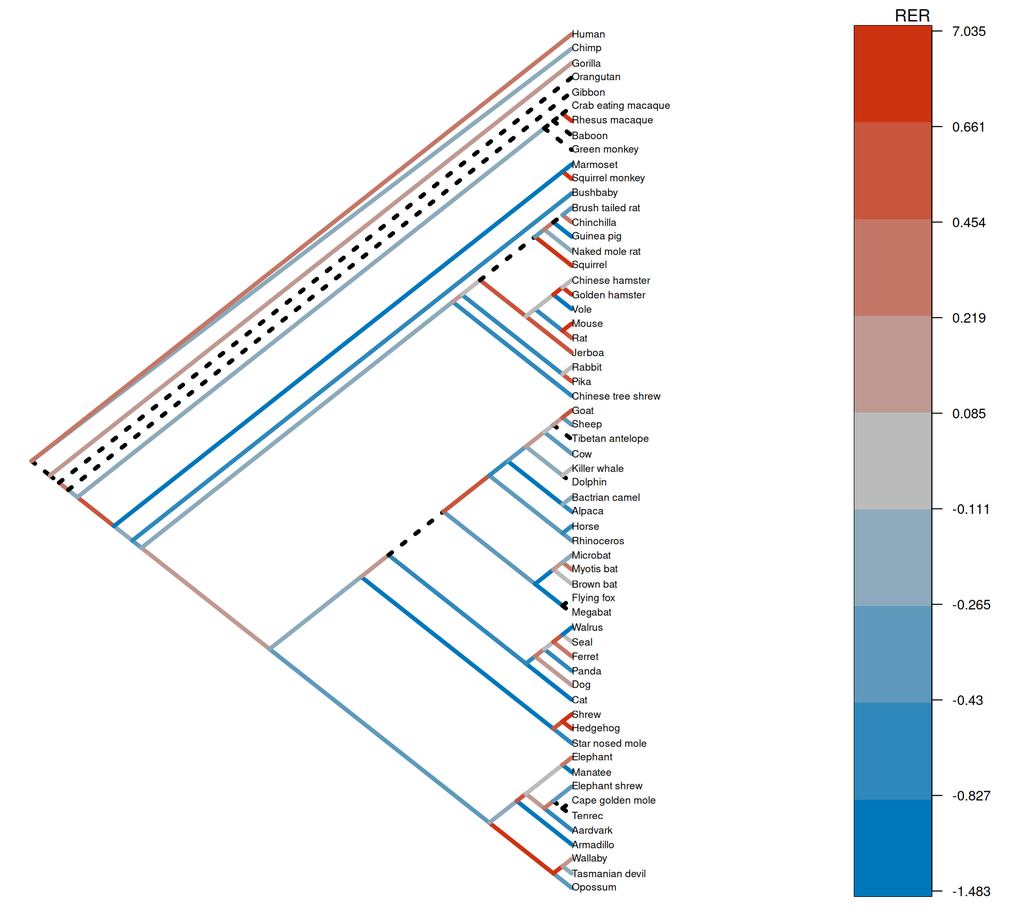

```r
#visualize RERs along branches as a heatmap
newbend3rers = treePlotRers(treesObj=toyTrees, rermat=mamRERw, index="BEND3",
                            type="c", nlevels=9, figwid=10)
```

The heatmap has 9 colors, corresponding to `nlevels=9`. The breaks are determined by quantiles of the RER distribution, with separate quantiles computed for values below and above zero. Dashed lines indicate lineages that have been excluded (edge.length = NA). When using a different device, you may need to adjust the `figwid` variable to display the full phylogeny with optimal aesthetics. For more information on options that can be passed to this function, see the documentation for `treePlotNew`.

## Binary Trait Analysis

Now we will associate variation in these RERs with variation in a **binary trait** across the tree. To do so, we first need to provide information about which branches of the tree have the trait of interest (**foreground branches**). There are several possible ways to do this:

1. Provide a binary trait tree file. This should be a file in Newick format with branch lengths zero for background branches and one (or weights between zero and one) for foreground branches. Setting any branches to NA will exclude these branches from the analysis. An example binary tree file is provided in *inst/extdata/MarineTreeBinCommonNames.txt*. This tree must have the same topology as the master tree or a subset of the master tree.

```
## Found more than one class "phylo" in cache; using the first, from namespace 'TreeTools'
```

```
## Also defined by 'tidytree'
```

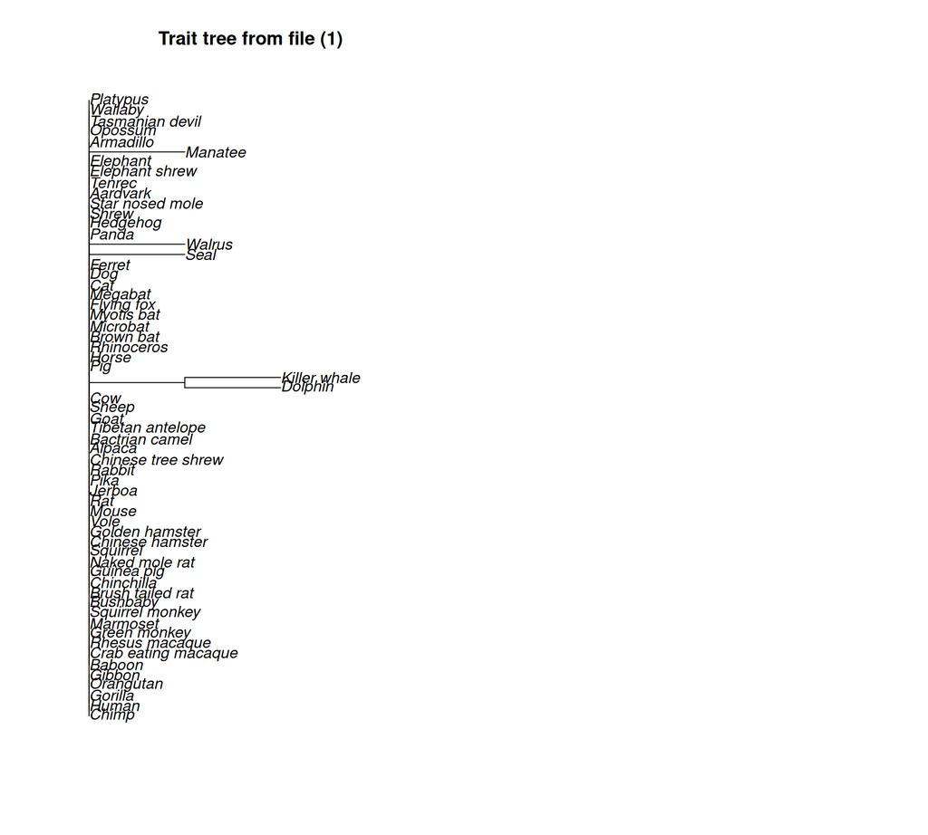

```r
marineb=read.tree(paste(rerpath,"/extdata/MarineTreeBinCommonNames_noCGM.txt",sep=""))
marinebrooted = root(marineb,outgroup=noneutherians)
par(mfrow=c(1,2))
plot(marinebrooted, main="Trait tree from file (1)")
#alternative way of representing the tree
mb1 = marineb
mb1$edge.length = c(rep(1,length(mb1$edge.length)))
binplot1=plotTreeHighlightBranches(mb1, outgroup=noneutherians,
                                   hlspecies=which(marineb$edge.length==1), hlcols="blue",
                                   main="Foreground branches highlighted (1)")
```

2. Generate a binary tree from a vector of foreground species using `foreground2Tree`. This uses the following input variables (all the options set here are also the defaults):
- `clade`: which of the branches within a foreground clade to keep as foreground. Options are “ancestral” to keep only the inferred transition branch, “terminal” to keep only terminal branches, and “all” to keep all branches.
- `transition`: whether to allow only transitions to the foreground state (“unidirectional”, the default) or both to and from the foreground state (“bidirectional”). Since we are considering transitions to a marine environment, which has only occurred in one direction within mammals, we use “unidirectional” (the default) here.
- `weighted`: whether to distribute the “weight” of the foreground specification across all branches within each independent clade (default: FALSE).
- `useSpecies`: a vector that can be used to specify a subset of species to use in the analysis. These should be the same species used to estimate RER.

We can visualize how several possible choices influence the output binary phenotype tree, as follows:

2a) `clade = "ancestral"`: Use maximum parsimony to infer where transitions from background to foreground occurred in the tree, and set those transition lineages to foreground.

```r
marineextantforeground = c("Walrus","Seal","Killer_whale","Dolphin","Manatee")
marineb2a = foreground2Tree(marineextantforeground, toyTrees, clade="ancestral",
                            useSpecies=names(logAdultWeightcm))
```

```
## Species from master tree not present in useSpecies: Cape_golden_mole
```

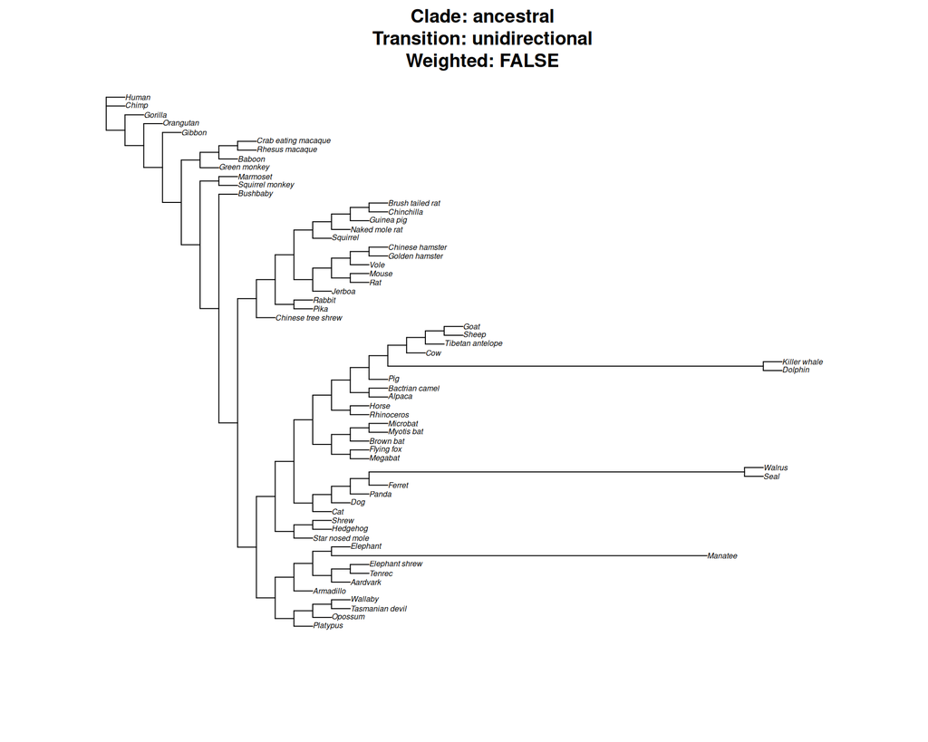

The output first indicates that there is one species in the master tree that is not in the list of species we requested to be included using `useSpecies`: the cape golden mole. This species will be excluded from our analysis.

The plot shows that the branch leading to the common ancestor of killer whale and dolphin, as well as the branch leading to the common ancestor of walrus and seal, are foreground, along with the terminal branch leading to the manatee.

2b) `clade = "terminal"`: Set only terminal lineages leading to foreground species as foreground.

```r
marineb2b = foreground2Tree(marineextantforeground, toyTrees, clade="terminal",
                            useSpecies=names(logAdultWeightcm))
```

```
## Species from master tree not present in useSpecies: Cape_golden_mole
```

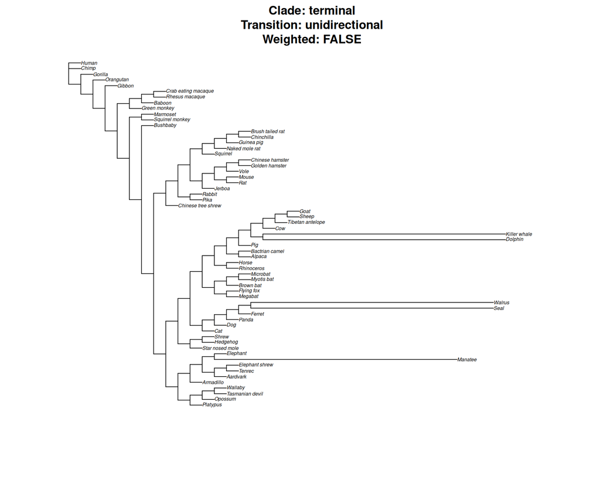

Here the each terminal branch leading to a marine species is foreground, but no internal branches are foreground.

2c) `clade = "all"`: Use maximum parsimony to infer where transitions from background to foreground occurred in the tree, and set those transition lineages, along with all daughter lineages, to foreground.

```r
marineb2c = foreground2Tree(marineextantforeground, toyTrees, clade="all",
                            useSpecies=names(logAdultWeightcm))
```

```
## Species from master tree not present in useSpecies: Cape_golden_mole
```

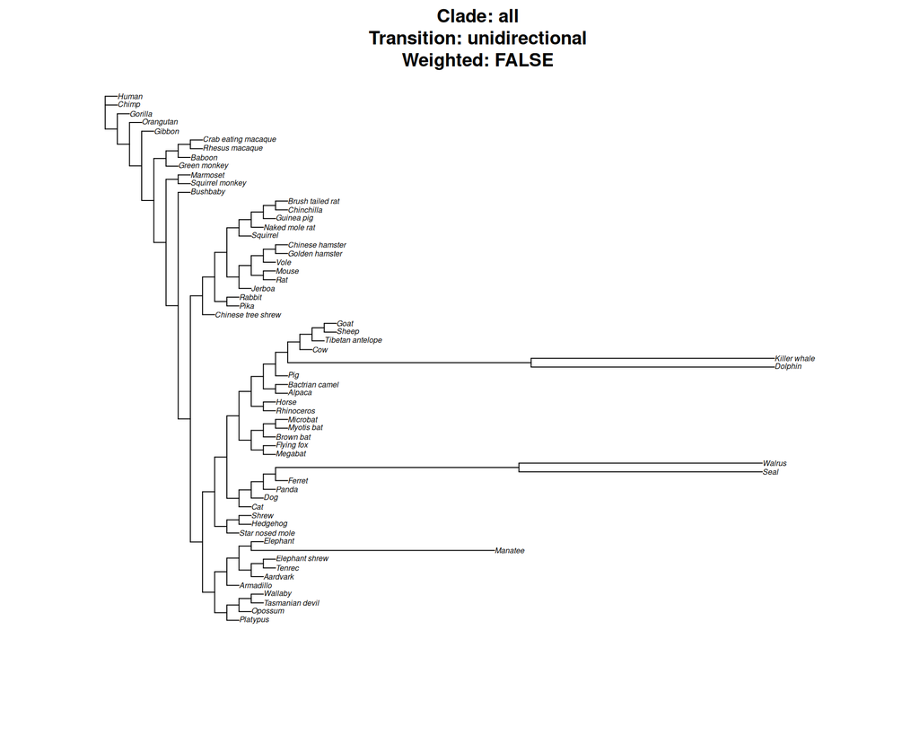

Here the foreground branches are all those inferred to be transitional from 2a, as well as the terminal branches. If we had a case in which some branches daughter to the transition branches were not terminal, those would be included in the foreground as well.

2d) `clade = "all"` and `weighted = TRUE`: Infer transition and daughter branches as in 2c, but spread a weight of 1 evenly across all branches within each independent foreground clade.

```r
marineb2d = foreground2Tree(marineextantforeground, toyTrees, clade="all", weighted = TRUE,
                            useSpecies=names(logAdultWeightcm))
```

```
## Species from master tree not present in useSpecies: Cape_golden_mole
```

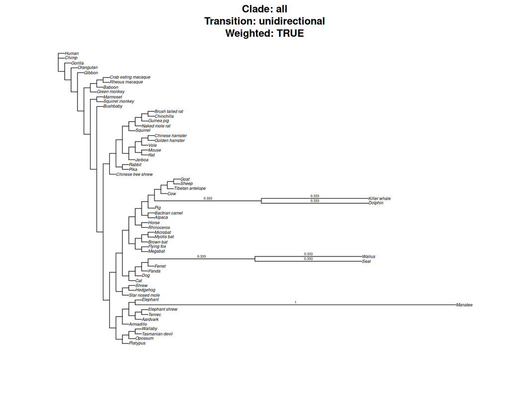

Here all branches in the cetacean and pinniped clades have length 1/3, whereas the terminal branch leading to the manatee has length 1. This is a way of distributing the weight given to each independent convergence event evenly across clades, rather than across lineages.

If you plot all the resulting trees, you can see how the different choices for `clade` influence the resulting branch lengths.

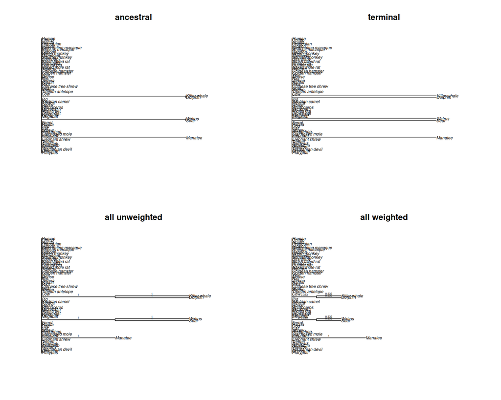

```r
par(mfrow=c(2,2))
plot(marineb2a,cex=0.6,main="ancestral")
plot(marineb2b,cex=0.6,main="terminal")
plot(marineb2c,cex=0.6,main="all unweighted", x.lim=c(0,2.5))
labs2c = round(marineb2c$edge.length,3)
labs2c[labs2c==0] = NA
edgelabels(labs2c, col = 'black', bg = 'transparent', adj = c(0.5,-0.5),cex = 0.4,frame='n')
plot(marineb2d,cex=0.6,main="all weighted", x.lim=c(0,2.5))
labs2d = round(marineb2d$edge.length,3)
labs2d[labs2d==0] = NA
edgelabels(labs2d, col = 'black', bg = 'transparent', adj = c(0.5,-0.5),cex = 0.4,frame='n')
```

None of these are the same as the binary tree that you specified in (1)!

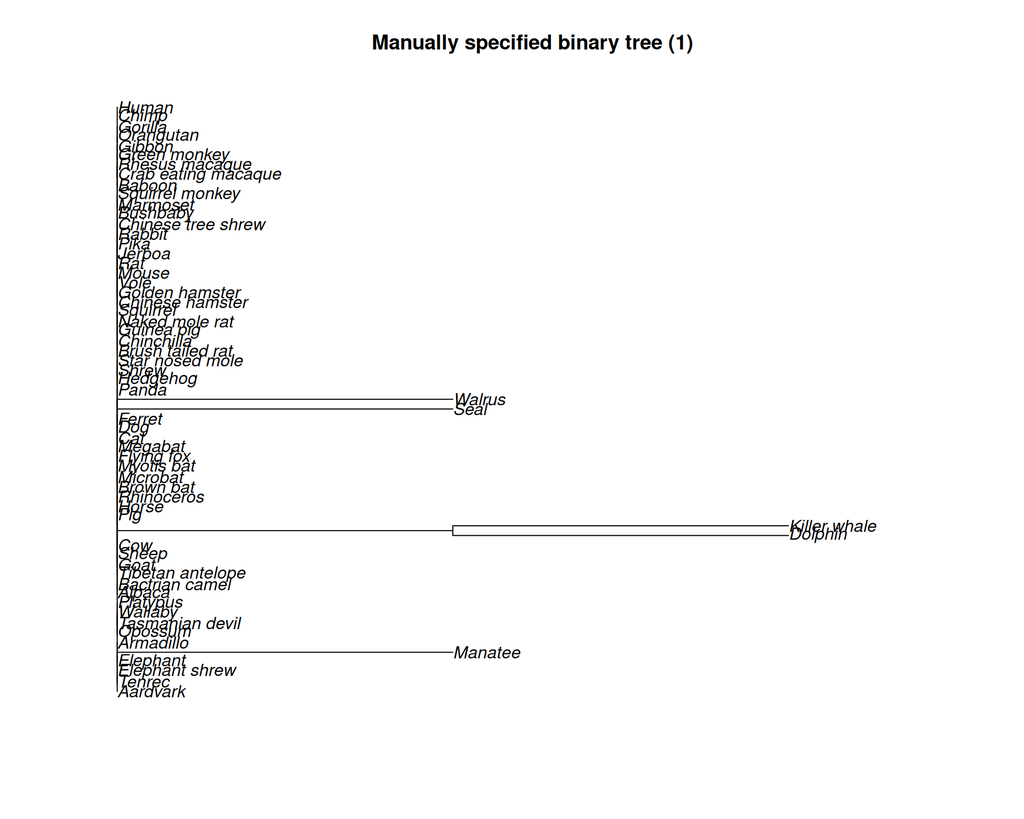

```r
plot(marineb,main="Manually specified binary tree (1)")
```

Note that, in this tree, the branch representing the ancestor of the killer whale and the dolphin has a branch length of 1, whereas the branch representing the ancestor of seal and walrus has a branch length of 0. This shows that providing a binary trait tree file (1) allows you to specify which branches should be foreground with more flexibility than providing a set of foreground species to `foreground2Tree`.

3. Use the interactive branch selection tool. The following should open a plot of the master tree. When the GUI opens, select the marine foreground branches (Walrus, Seal, Killer whale, Dolphin, Killer whale-Dolphin ancestor, and Manatee), and click ‘End selection.’ Do not click ‘New category’.

```r
marineb3=click_select_foreground_branches(toyTrees$masterTree)
```

You can double check that the tree you created by manual selection (3) matches the binary tree you provided in (1) (it should) using the following code:

```r
marineb3rooted=root(marineb3,outgroup=c("Platypus", "Wallaby","Tasmanian_devil","Opossum"))
par(mfrow=c(1,2))
plot(marinebrooted, main = "Provided binary tree (1)")
plot(marineb3rooted, main = "Trait tree from manual selection (3)")
```

## Generating **paths** using `tree2Paths` or `foreground2Paths`

Some of the genes (like BEND3 above) may not have data for all species, meaning that their phylogeny will be a subset of the full phylogeny. To plot RERs for these genes and to correlate them with trait evolution, we run one of two functions that determine how the trait would evolve along all/many possible subsets of the full phylogeny, generating a set of **paths**. The function `tree2Paths` takes a binary tree as input, and the function `foreground2Paths` takes a set of foreground species as input. `foreground2Paths` has the same arguments as `foreground2Tree` described above (see option 2 in *Reading in or generating trait trees*).

**Important note**: If you are using a binary tree to create paths, it **must** have the same topology as the **master tree** or a subset of the **master tree** (see previous section for how this is generated).

```r
phenvMarine=tree2Paths(marineb, toyTrees)
phenvMarine2=foreground2Paths(marineextantforeground, toyTrees, clade="all")
phenvMarine2b=tree2Paths(marineb2b, toyTrees)
```

## Correlating gene evolution with binary trait evolution using `correlateWithBinaryPhenotype`

Now that we have estimates for the RERs for all genes of interest, as well as a representation of how the trait of interest evolves across the tree, we can use `correlateWithBinaryPhenotype` to test for an association between relative evolutionary rate and trait across all branches of the tree.

This uses the following input variables (all the options set here are also the defaults):

- `min.sp`: the minimum number of species in the gene tree for that gene to be included in the analysis. The default is 10, but you may wish to modify it depending upon the number of species in your master tree.
- `min.pos`: the minimum number of independent foreground (non-zero) lineages represented in the gene tree for that gene to be included in the analysis. The default is 2, requiring at least two foreground lineages to be present in the gene tree.
- `weighted`: whether to perform a weighted correlation where branch lengths represent weights. This can be used with the `weighted=TRUE` option in `foreground2Tree` or `foreground2Paths` to distribute phenotype weights across multiple lineages in a clade. The default is “auto”, which will use weighted correlation if any branch lengths are between 0 and 1, and will use standard correlation otherwise.
- `winsorizeRER`/`winsorizetrait`: pulls the most extreme N values (default N=3) in both the positive and negative tails to the value of the N+1 most extreme value. This process mitigates the effect of extreme outliers before calculating correlations.
- `bootstrap`/`bootn`: Sets up for bootstrapping. `bootstrap` dictates whether the trees will be bootstrapped, and `bootn` represents how many iterations. We advise against both winsorizing and bootstrapping - either is good, but both is overkill.

```r
corMarine=correlateWithBinaryPhenotype(mamRERw, phenvMarine, min.sp=10, min.pos=2,
                                       weighted="auto", winsorizeRER=NULL, winsorizetrait=NULL,
                                       bootstrap=FALSE, bootn=1000)
```

```
## Used an  unweighted Kendall correlation.
```

The text displayed shows which correlation method is used to test for association. Here it uses the default for binary traits: the Kendall rank correlation coefficient, or Tau.

The `correlateWithBinaryPhenotype` function generates a table with the following output for each gene:

1. Rho: the correlation between relative evolutionary rate and trait across all branches
2. N: the number of branches in the gene tree
3. P: an estimate of the P-value for association between relative evolutionary rate and trait.
4. p.adj: an estimate of the P-value adjusted for multiple comparisons using the Benjamini-Hochberg procedure (i.e., an estimate of the false discovery rate, or FDR).

Let’s take a look at some of the top genes within this set.

```r
head(corMarine[order(corMarine$P),])
```

```
##                 Rho   N            P     p.adj
## TTN       0.2530025 119 0.0008025188 0.1966832
## ANO2      0.2637782 106 0.0009846226 0.1966832
## BDH1      0.2600310 102 0.0014474106 0.1966832
## CASP16    0.2569824 101 0.0017367170 0.1966832
## C1orf101 -0.2369922 109 0.0026761712 0.2424611
## ASB15     0.2319542 107 0.0035997511 0.2568374
```

```r
  corMarine$stat = -log10(corMarine$P) * sign(corMarine$Rho)
  head(corMarine[order(corMarine$stat, decreasing = TRUE),])
```

```
##              Rho   N            P     p.adj     stat
## TTN    0.2530025 119 0.0008025188 0.1966832 3.095545
## ANO2   0.2637782 106 0.0009846226 0.1966832 3.006730
## BDH1   0.2600310 102 0.0014474106 0.1966832 2.839408
## CASP16 0.2569824 101 0.0017367170 0.1966832 2.760271
## ASB15  0.2319542 107 0.0035997511 0.2568374 2.443728
## ATP2A1 0.2363641 101 0.0039687905 0.2568374 2.401342
```

*ANO2* and *BMP10* are two of the top genes in the positive and negative directions, respectively. Let’s examine their RER plots.

```
## Used an  unweighted Kendall correlation.
```

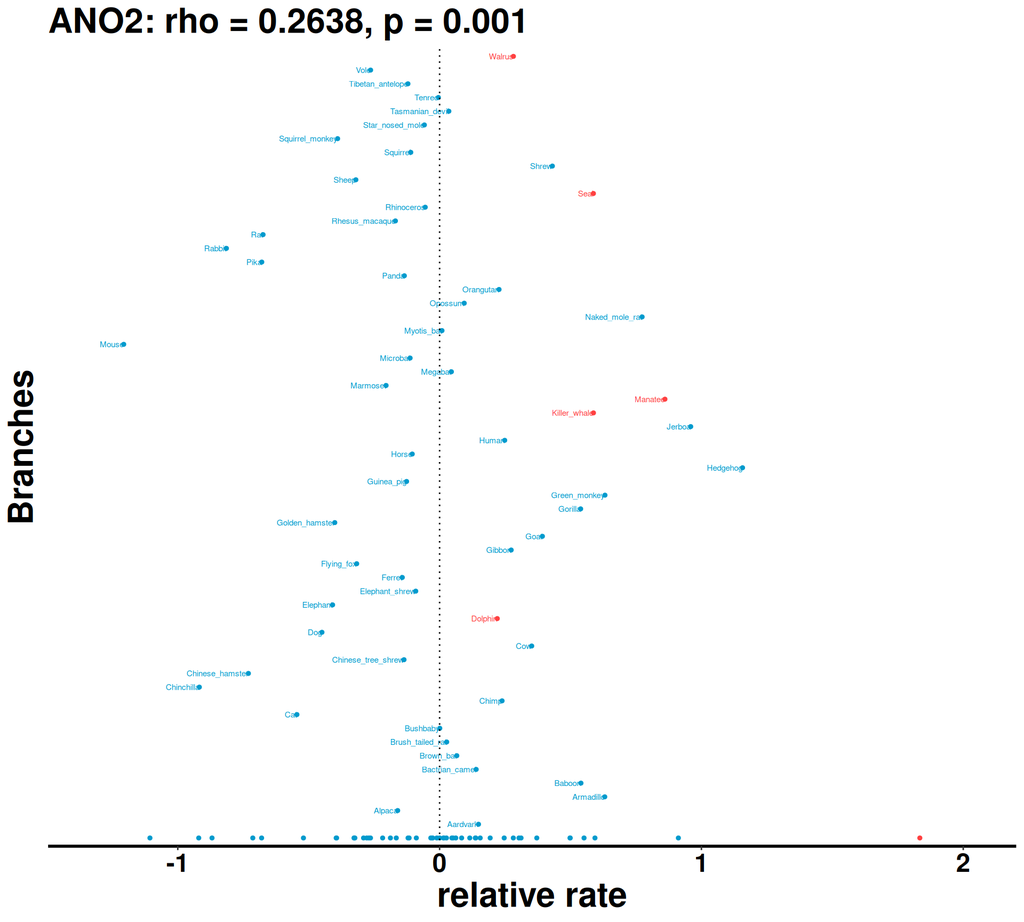

```r
plotRers(mamRERw,"ANO2",phenv=phenvMarine)
```